# Data Challenge

# Data exploration

```
## # A tibble: 15 × 2
##    reh       n
##    <chr> <int>
##  1 RE01   1951
##  2 RE02   6019
##  3 RE03   5403
##  4 RE04   1895
##  5 RE05   6714
##  6 RE06   6187
##  7 RE07   3725
##  8 RE08   6548
##  9 RE09   6639
## 10 RE10   6924
## 11 RE11   5599
## 12 RE12   7289
## 13 RE13   7800
## 14 RE14   2465
## 15 RE15   5867
```

```
##     latitude       longitude           y                x
##  Min.   :47.17   Min.   :8.496   Min.   :680024   Min.   :225196
##  1st Qu.:47.23   1st Qu.:8.521   1st Qu.:681910   1st Qu.:231974
##  Median :47.28   Median :8.555   Median :684468   Median :237349
##  Mean   :47.27   Mean   :8.548   Mean   :683921   Mean   :235882
##  3rd Qu.:47.29   3rd Qu.:8.569   3rd Qu.:685534   3rd Qu.:238217
##  Max.   :47.30   Max.   :8.597   Max.   :687703   Max.   :239875
##      reh             datetime_utc
##  Length:81025       Min.   :2013-09-12 23:01:02
##  Class :character   1st Qu.:2014-05-01 17:50:11
##  Mode  :character   Median :2014-10-22 17:01:18
##                     Mean   :2014-10-21 10:35:57
##                     3rd Qu.:2015-03-26 11:00:44
##                     Max.   :2016-07-04 23:20:21
```

```
## spec_tbl_df [81,025 × 6] (S3: spec_tbl_df/tbl_df/tbl/data.frame)
##  $ latitude    : num [1:81025] 47.3 47.3 47.3 47.3 47.3 ...
##  $ longitude   : num [1:81025] 8.57 8.57 8.57 8.57 8.57 ...
##  $ y           : num [1:81025] 685545 685552 685534 685557 685634 ...
##  $ x           : num [1:81025] 235920 235919 235917 235933 235946 ...
##  $ reh         : chr [1:81025] "RE01" "RE01" "RE01" "RE01" ...
##  $ datetime_utc: POSIXct[1:81025], format: "2013-09-12 23:01:30" "2013-09-13 02:01:00" ...
##  - attr(*, "spec")=
##   .. cols(
##   ..   latitude = col_double(),
##   ..   longitude = col_double(),
##   ..   y = col_double(),
##   ..   x = col_double(),
##   ..   reh = col_character(),
##   ..   datetime_utc = col_datetime(format = "")
##   .. )
##  - attr(*, "problems")=<externalptr>
```

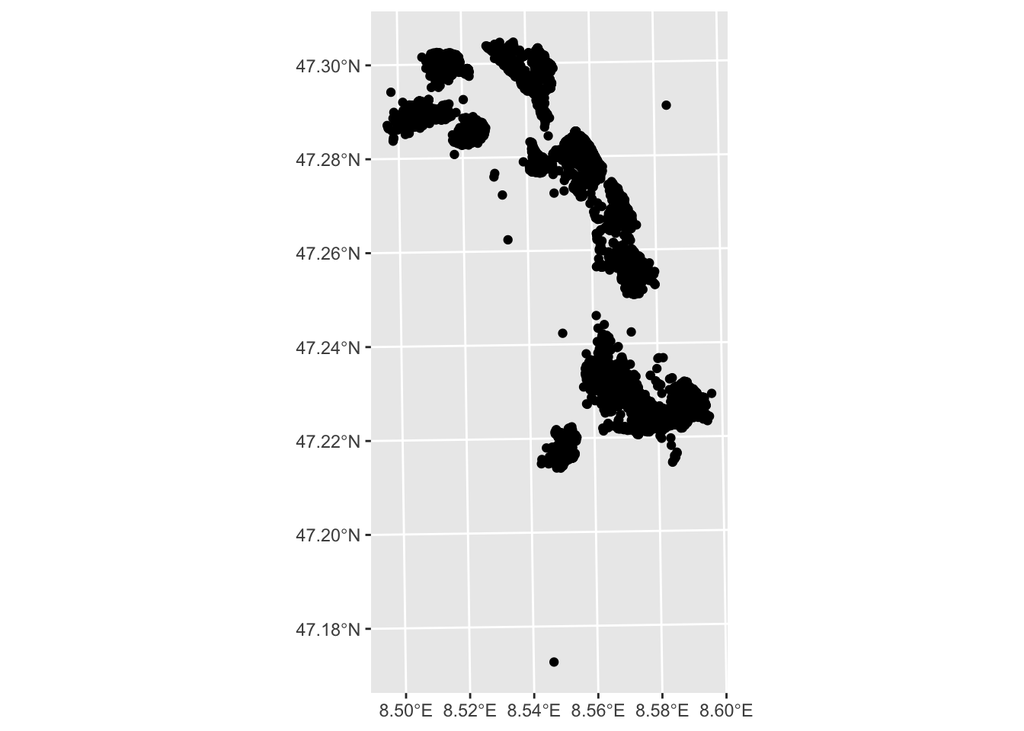

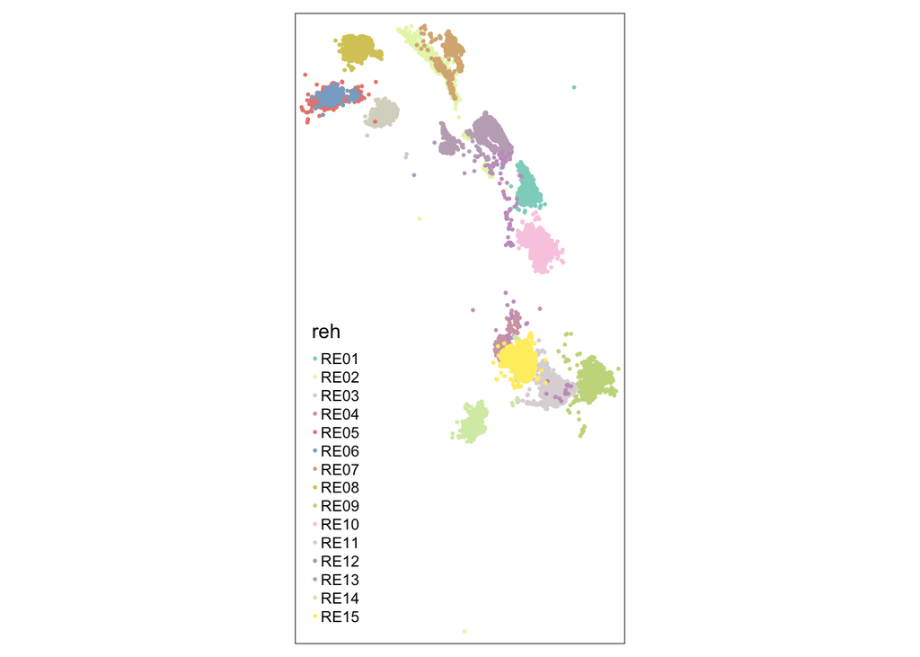

## Areal Extent

Does each deer have an area/revier and is there an overlap?

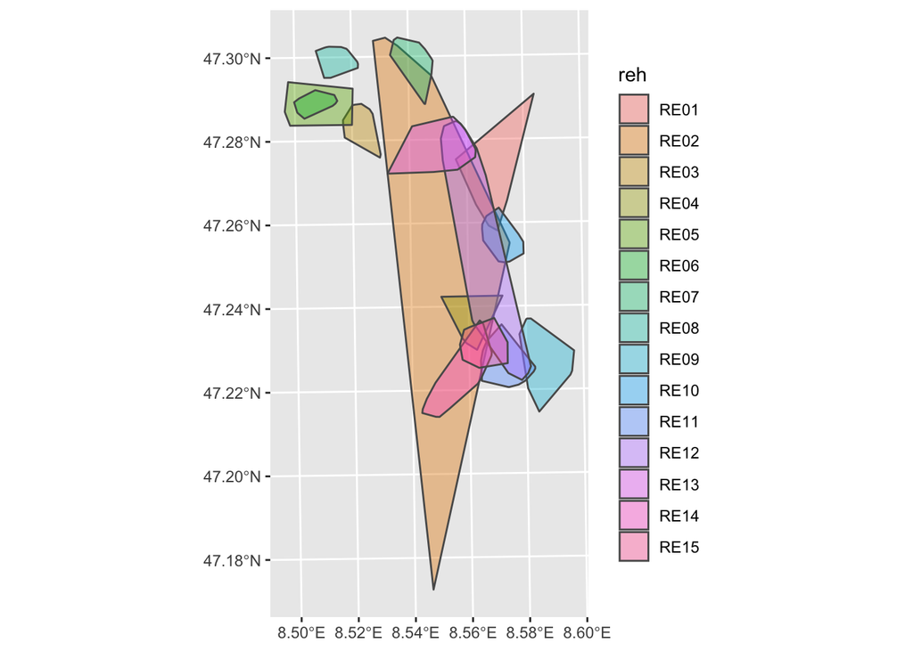

## Analysing trajectory data Lets get time data etc

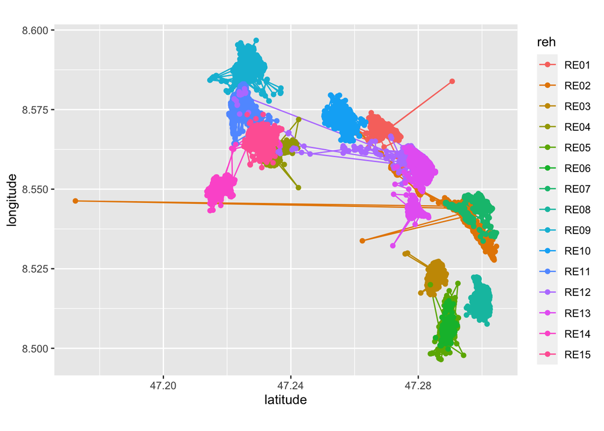

Time plots

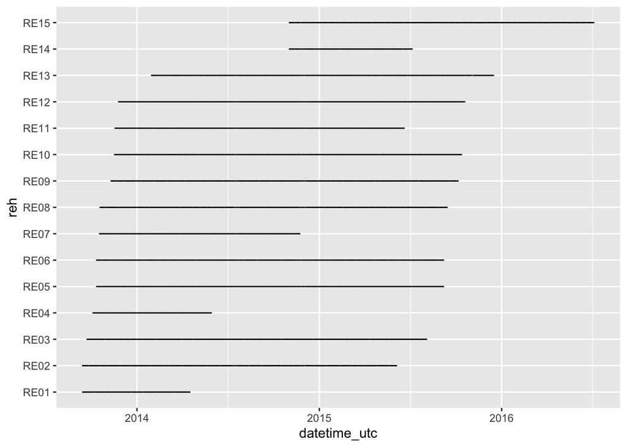

[figure not shown]

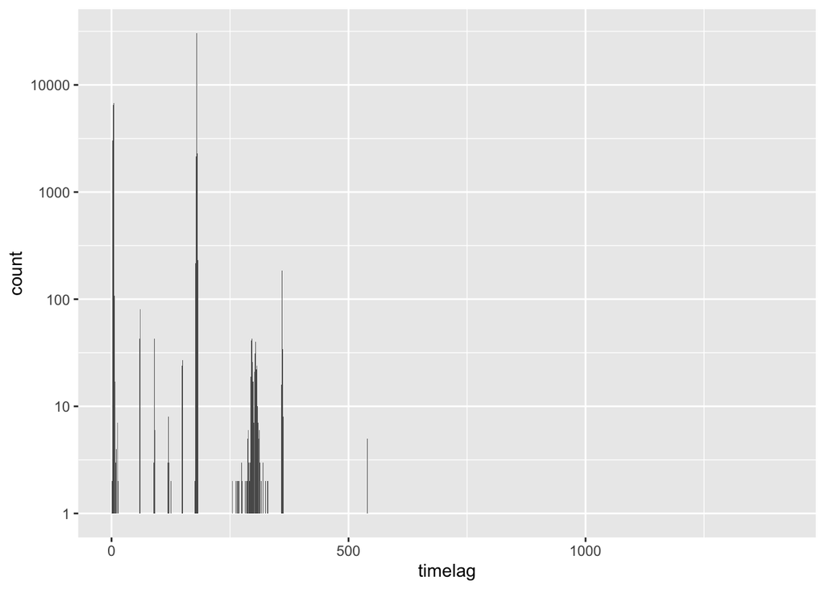

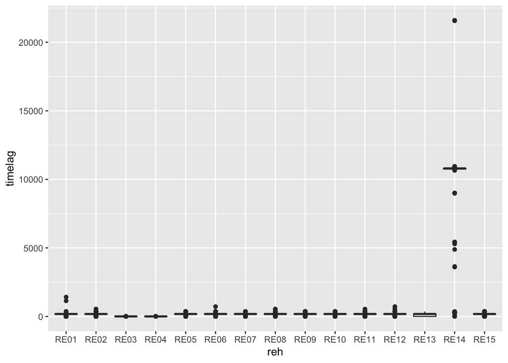

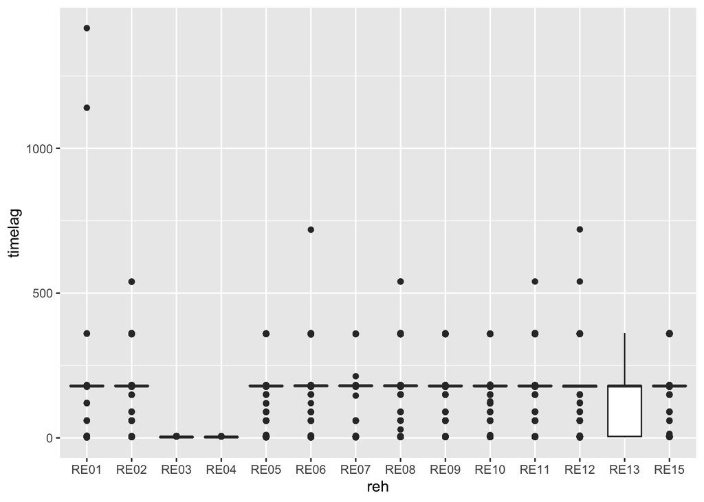

```
##     latitude       longitude           y                x
##  Min.   :47.17   Min.   :8.496   Min.   :680024   Min.   :225196
##  1st Qu.:47.24   1st Qu.:8.521   1st Qu.:681841   1st Qu.:232228
##  Median :47.28   Median :8.556   Median :684523   Median :237372
##  Mean   :47.27   Mean   :8.548   Mean   :683912   Mean   :236060
##  3rd Qu.:47.29   3rd Qu.:8.569   3rd Qu.:685580   3rd Qu.:238223
##  Max.   :47.30   Max.   :8.597   Max.   :687703   Max.   :239875
##
##      reh             datetime_utc                    timelag
##  Length:78560       Min.   :2013-09-12 23:01:02   Min.   :   1.0
##  Class :character   1st Qu.:2014-04-29 17:00:43   1st Qu.:   5.0
##  Mode  :character   Median :2014-10-09 17:00:44   Median : 179.0
##                     Mean   :2014-10-17 19:35:45   Mean   : 133.9
##                     3rd Qu.:2015-03-24 02:01:09   3rd Qu.: 180.0
##                     Max.   :2016-07-04 23:20:21   Max.   :1415.0
##                                                   NA's   :14
```

It is clear that our average timelag is around 3 minutes - with some lower points dragging the mean down.

## Calculating speed

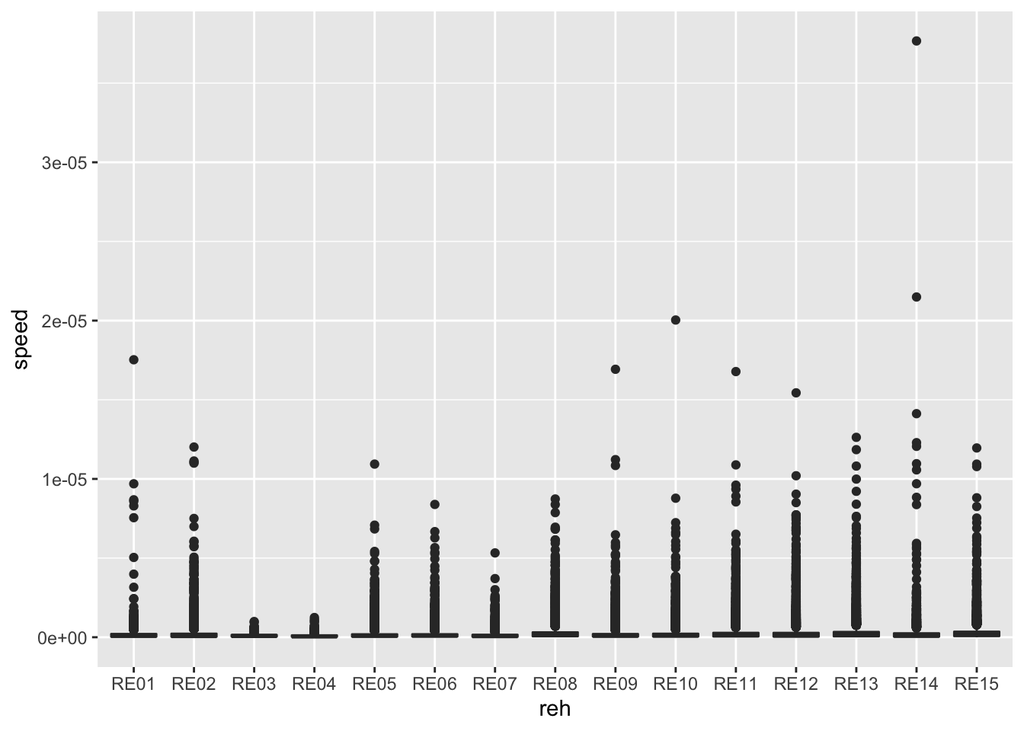

Now lets perform the trajectory analysis.

1 sample is 3 minutes so if we take a window of 18 minutes we use a window size of 6 positions

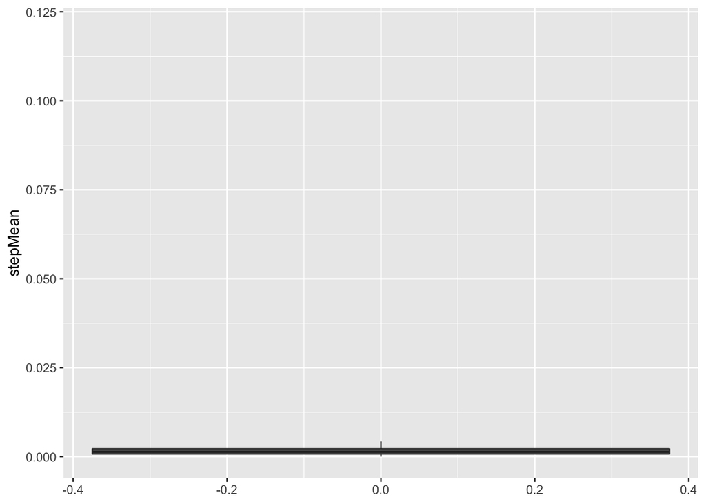

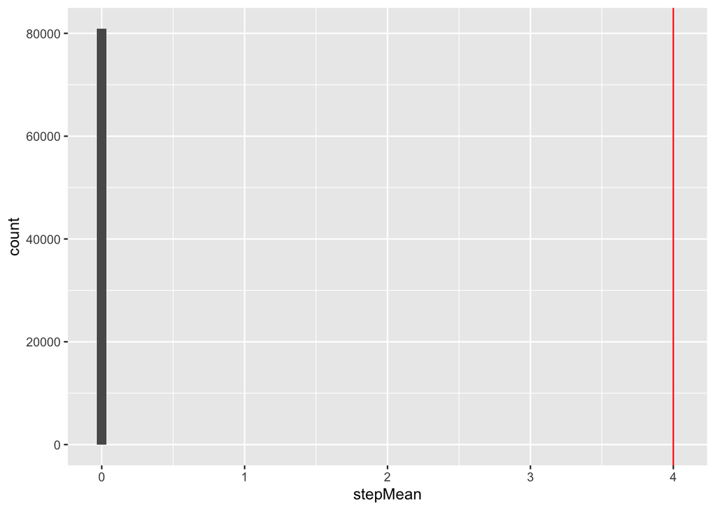

```
##    Min. 1st Qu.  Median    Mean 3rd Qu.    Max.    NA's
## 0.00001 0.00078 0.00140 0.00160 0.00219 0.12017      90
```

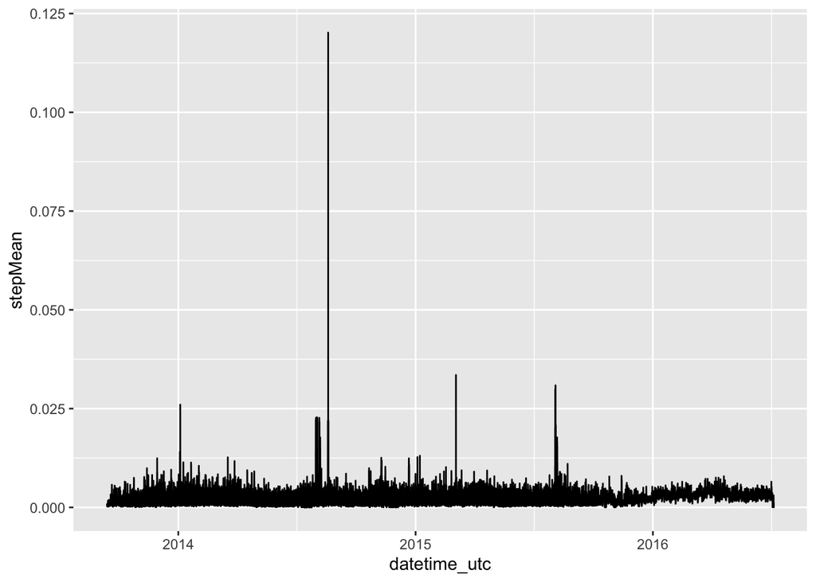

[figure not shown]

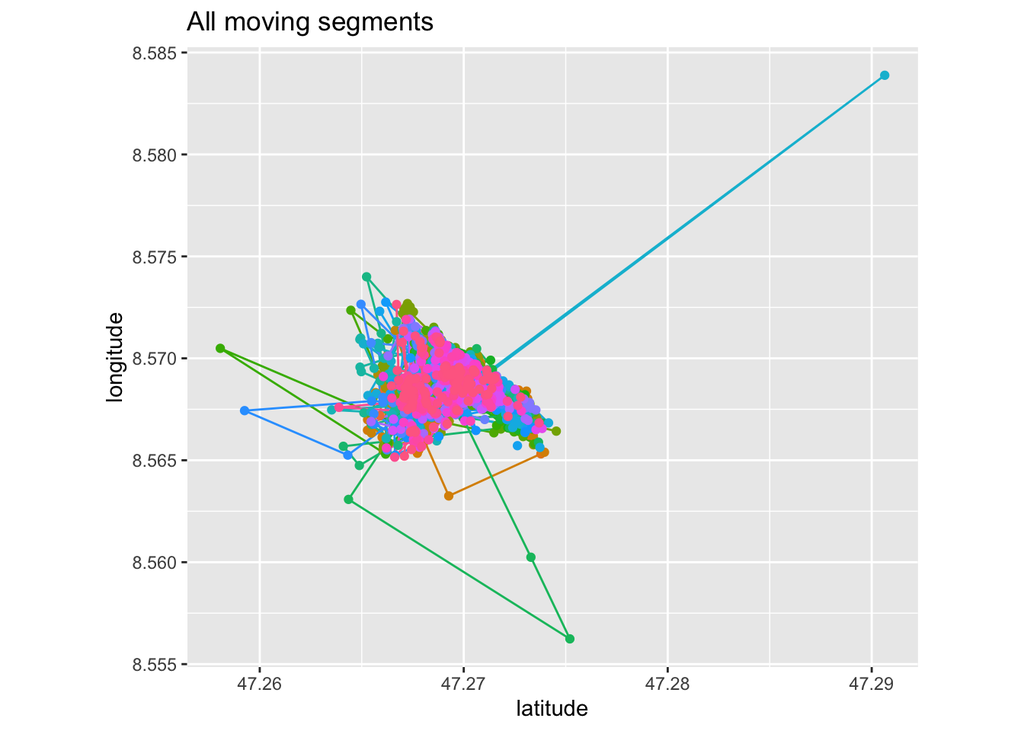